# solution_1

2024-09-02

### Names:

Group:13  
Nina Geyer

## Part 1: Explanatory analysis of the dataset

### Assumptions:

- linearity of covariate effects
- homescedasticity of error variance –> error variacnce same for different dependent variables
- uncorrelated error
- additivity of errors

### Diagnostics plots:

```r
#install.packages("car")
library(car)
library(GGally)
```

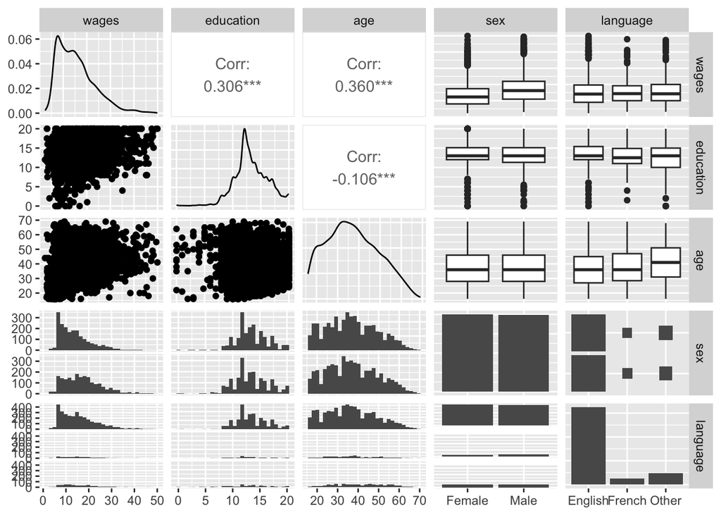

```r
data(SLID, package = "carData")
SLID <- SLID[complete.cases(SLID), ]
ggpairs(SLID)
```

### Relations:

- There is a medium strong (Cohen), positive correlation between education and wages and age and wages –> good if we want to predict wages, bad if not, because then there might be multicollinearity
- There is a weak (Cohen), negative correlation between age and education –> again good for prediction of one of them, but bad if not
- There seems to be a small difference in wages between the sexes (males gaining more than females)
- No difference in wages regarding the language level
- About same distribution of education and age regarding sex

## Part 2: Linear regression with the mylm package

### Questions:

What is the interpretation of the parameter estimates?

- The parameter estimation shows the influence or strength of influence of the covariate on the dependent variable.
- The z- and p-values show if this effect in the linear regression is significant or not, so if it would show as well, if we would repeat the experiment.
- The intercept shows the value of the dependent varaible if all covariates are 0.

```r
#install.packages("car")
#install.packages("mylm")
library(mylm)
library(car)
library(GGally)
library(stringr)
data(SLID, package = "carData")
SLID <- SLID[complete.cases(SLID), ]

# comparison simple model
model1 <- mylm(wages ~ education, data = SLID)
model1b <- lm(wages ~ education, data = SLID)

# print
print.mylm(model1)
```

```
## Call:
## mylm(formula = wages ~ education, data = SLID)
##
## Coefficients:
## (Intercept) : 4.9717
## education : 0.7923
```

```r
# summary
summary.mylm(model1)
```

```
## Call:
## mylm(formula = wages ~ education, data = SLID)
##
## Residuals:
## Min       1Q        Median    3Q        Max
## -17.688   -5.822    -1.039    4.148     34.190
##
## Coefficients:
##               Estimate     Std. Error   z value      Pr(>|z|)
## (Intercept)   4.971691     0.5344       9.3040       0.0000 ***
## education     0.7923091    0.0391       20.2816      0.0000 ***
##
## Signif. codes:  0 ‘***’ 0.001 ‘**’ 0.01 ‘*’ 0.05 ‘.’ 0.1 ‘ ’ 1
## Residual standard error:  7.493 on  3984 degrees of freedom
## Multiple R-squared:  0.09359 ,  Adjusted R-squared:  0.09313
## F-statistic:  411.3 on 1 and 3984 DF, p-value: 0.000
```

```r
summary(model1b)
```

```
##
## Call:
## lm(formula = wages ~ education, data = SLID)
##
## Residuals:
##     Min      1Q  Median      3Q     Max
## -17.688  -5.822  -1.039   4.148  34.190
##
## Coefficients:
##             Estimate Std. Error t value Pr(>|t|)
## (Intercept)  4.97169    0.53429   9.305   <2e-16 ***
## education    0.79231    0.03906  20.284   <2e-16 ***
## ---
## Signif. codes:  0 '***' 0.001 '**' 0.01 '*' 0.05 '.' 0.1 ' ' 1
##
## Residual standard error: 7.492 on 3985 degrees of freedom
## Multiple R-squared:  0.09359,    Adjusted R-squared:  0.09336
## F-statistic: 411.4 on 1 and 3985 DF,  p-value: < 2.2e-16
```

### Plot

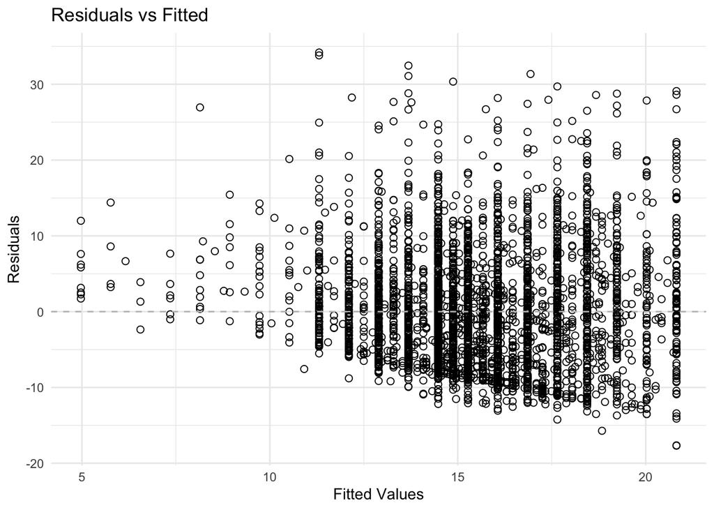

```r
library(mylm)
model1 <- mylm(wages ~ education, data = SLID)
plot.mylm(model1)
```

### Comments:

- Heteroscadicity, so for larger fitted values the prediction gets less precise and the errors are more widely spread –> This indicates that there might be an error in the way the covariates are modelled.
- We have only little data for the higher values of wages, so this might make the prediction harder as there is less to fit/ learn from.
- Also, the distribution for the positive residuals has a higher variance than for the negative one.

### ANOVA

- What is the residual sum of squares (SSE) and the degrees of freedom for this model? See output.
- What is total sum of squares (SST) for this model? Test the significance of the regression using a $\chi^2$-test. 23096 (Sum Sq education) + 223694 (sum sq residuals) = 246790. Test is in the output and shows significant explanation of variance.
- What is the relationship between the $\chi^2$- and $z$-statistic in simple linear regression? Find the critical value(s) for both tests. As there is only one beta to test in simple linear regression the $\chi^2$ for the whole model should be the squared z statistic for education, which is true for our values $\chi^2$ = 411 and z = 20.284 (20.284^2 = 411.44).

```r
library(mylm)
library(stringr)
model1 <- mylm(wages ~ education, data = SLID)
anova.mylm(model1)
```

```
## [1] "wages~"
## Analysis of Variance Table
## Response: wages
##               Df         Sum Sq     Mean Sq    Chi^2      Pr(>Chi^2)
## education     1          23096      23096      411.447    0 ***
## Residuals     3984       223694     56
## Signif. codes:  0 ‘***’ 0.001 ‘**’ 0.01 ‘*’ 0.05 ‘.’ 0.1 ‘ ’ 1
## Total Sum SQ: 246790
## Chi-statistic:  411.3 on 3984 DF, p-value: 0.000
```

### Comments:

- The covariate education gets a significant $\chi^2$ value which means there is a high probability that it explains variance of the dependent variable.

# Part 3: Multiple Linear Regression

- What are the estimates and standard errors of the intercepts and regression coefficients for this model?
- Test the significance of the coefficients using a $z$-test.

```r
library(mylm)
library(stringr)
model1d <- mylm(wages ~ education + age, data = SLID)
summary.mylm(model1d)
```

```
## Call:
## mylm(formula = wages ~ education + age, data = SLID)
##
## Residuals:
## Min       1Q        Median    3Q        Max
## -24.303   -4.495    -0.807    3.674     37.628
##
## Coefficients:
##               Estimate     Std. Error   z value      Pr(>|z|)
## (Intercept)   -6.021653    0.6190       -9.7280      0.0000 ***
## education     0.9014644    0.0358       25.2057      0.0000 ***
## age           0.2570898    0.0090       28.7176      0.0000 ***
##
## Signif. codes:  0 ‘***’ 0.001 ‘**’ 0.01 ‘*’ 0.05 ‘.’ 0.1 ‘ ’ 1
## Residual standard error:  6.821 on  3983 degrees of freedom
## Multiple R-squared:  0.2491 ,  Adjusted R-squared:  0.2485
## F-statistic:  660.5 on 2 and 3983 DF, p-value: 0.000
```

What is the interpretation of the parameters?

- The intercept is negative, probably because all data points (persons) have an age higher than 0.
- Education seems to have a higher influence than age as the parameter estimate is higher.
- Both parameters are significant, so should have an influence on wages.

### Comparison simple linear regression and multiple linear regression

```r
library(mylm)
model1 <- mylm(wages ~ education, data = SLID)
summary.mylm(model1)
```

```
## Call:
## mylm(formula = wages ~ education, data = SLID)
##
## Residuals:
## Min       1Q        Median    3Q        Max
## -17.688   -5.822    -1.039    4.148     34.190
##
## Coefficients:
##               Estimate     Std. Error   z value      Pr(>|z|)
## (Intercept)   4.971691     0.5344       9.3040       0.0000 ***
## education     0.7923091    0.0391       20.2816      0.0000 ***
##
## Signif. codes:  0 ‘***’ 0.001 ‘**’ 0.01 ‘*’ 0.05 ‘.’ 0.1 ‘ ’ 1
## Residual standard error:  7.493 on  3984 degrees of freedom
## Multiple R-squared:  0.09359 ,  Adjusted R-squared:  0.09313
## F-statistic:  411.3 on 1 and 3984 DF, p-value: 0.000
```

```r
model1c <- mylm(wages ~ age , data = SLID)
summary.mylm(model1c)
```

```
## Call:
## mylm(formula = wages ~ age, data = SLID)
##
## Residuals:
## Min       1Q        Median    3Q        Max
## -17.747   -4.847    -1.507    3.914     35.063
##
## Coefficients:
##               Estimate     Std. Error   z value      Pr(>|z|)
## (Intercept)   6.890901     0.3741       18.4202      0.0000 ***
## age           0.2331079    0.0096       24.3222      0.0000 ***
##
## Signif. codes:  0 ‘***’ 0.001 ‘**’ 0.01 ‘*’ 0.05 ‘.’ 0.1 ‘ ’ 1
## Residual standard error:  7.344 on  3984 degrees of freedom
## Multiple R-squared:  0.1293 ,  Adjusted R-squared:  0.1289
## F-statistic:  591.6 on 1 and 3984 DF, p-value: 0.000
```

```r
model2 <- mylm(wages ~ education + age, data = SLID)
summary.mylm(model2)
```

```
## Call:
## mylm(formula = wages ~ education + age, data = SLID)
##
## Residuals:
## Min       1Q        Median    3Q        Max
## -24.303   -4.495    -0.807    3.674     37.628
##
## Coefficients:
##               Estimate     Std. Error   z value      Pr(>|z|)
## (Intercept)   -6.021653    0.6190       -9.7280      0.0000 ***
## education     0.9014644    0.0358       25.2057      0.0000 ***
## age           0.2570898    0.0090       28.7176      0.0000 ***
##
## Signif. codes:  0 ‘***’ 0.001 ‘**’ 0.01 ‘*’ 0.05 ‘.’ 0.1 ‘ ’ 1
## Residual standard error:  6.821 on  3983 degrees of freedom
## Multiple R-squared:  0.2491 ,  Adjusted R-squared:  0.2485
## F-statistic:  660.5 on 2 and 3983 DF, p-value: 0.000
```

```r
test <- mylm(age ~ education, data = SLID)
summary.mylm(test)
```

```
## Call:
## mylm(formula = age ~ education, data = SLID)
##
## Residuals:
## Min        1Q         Median     3Q         Max
## -25.9116   -8.9982    -0.6658    8.9097     33.8817
##
## Coefficients:
##               Estimate      Std. Error    z value       Pr(>|z|)
## (Intercept)   42.76072      0.8609        49.6726       0.0000 ***
## education     -0.4245804    0.0629        -6.7464       2e-11 ***
##
## Signif. codes:  0 ‘***’ 0.001 ‘**’ 0.01 ‘*’ 0.05 ‘.’ 0.1 ‘ ’ 1
## Residual standard error:  12.07 on  3984 degrees of freedom
## Multiple R-squared:  0.0113 ,  Adjusted R-squared:  0.0108
## F-statistic:  45.5 on 1 and 3984 DF, p-value: 2e-11
```

Why (and when) does the parameter estimates found (the two simple and the one multiple) differ?

- They should not differ, if the covariates so age and education are independent (no correlation).
- They differ because age and education are correlated. Explain/show how you can use mylm to find these values. –> Use the function on the model, if we want to know if there is a relationship between the variables, we can use the mylm function on them eg education and age.

# Part 4: Testing mylm

```r
library(mylm)
library(stringr)
model3 <- mylm(wages ~ sex + age + language + I(education^2), data = SLID)
summary.mylm(model3)
```

```
## Call:
## mylm(formula = wages ~ sex + age + language + I(education^2),
##     data = SLID)
##
## Residuals:
## Min        1Q         Median     3Q         Max
## -27.1712   -4.2762    -0.7631    3.2176     35.9289
##
## Coefficients:
##                  Estimate       Std. Error     z value        Pr(>|z|)
## (Intercept)      -1.875531      0.4404         -4.2587        2e-05 ***
## sexMale          3.4087         0.2084         16.3529        0.0000 ***
## age              0.248625       0.0087         28.6973        0.0000 ***
## languageFrench   -0.07553202    0.4252         -0.1776        0.8590
## languageOther    -0.1345402     0.3232         -0.4163        0.6772
## I(education^2)   0.03481515     0.0013         26.9873        0.0000 ***
##
## Signif. codes:  0 ‘***’ 0.001 ‘**’ 0.01 ‘*’ 0.05 ‘.’ 0.1 ‘ ’ 1
## Residual standard error:  6.578 on  3980 degrees of freedom
## Multiple R-squared:  0.3022 ,  Adjusted R-squared:  0.3012
## F-statistic:  344.8 on 5 and 3980 DF, p-value: 0.000
```

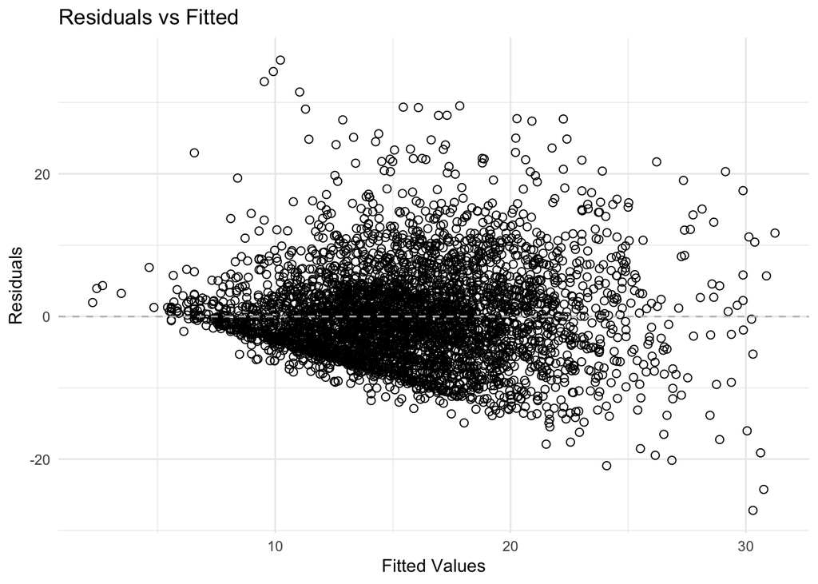

```r
plot.mylm(model3)
```

[output not shown]

[figure not shown]

[output not shown]

Language is still insignificant and age has a significant effect on wages. Also the interaction of languageFrench and age is significant. The model explains about 13% of the variance. The anova shows that age has the largest sum of squares which could indicate that age is explaining most of the variance in the regression. As the result of the anova is dependent upon the order we enter the variables to the model, this proposition might not hold in all models. In this model, we probably would add sex again, because it seems to explain a large proportion of variance.

```r
library(mylm)
library(stringr)
model5 <- mylm(wages ~ education - 1, data = SLID)
summary.mylm(model5)
```

```
## Call:
## mylm(formula = wages ~ education - 1, data = SLID)
##
## Residuals:
## Min        1Q         Median     3Q         Max
## -19.8039   -5.3421    -0.6624    4.4646     36.3264
##
## Coefficients:
##             Estimate    Std. Error  z value     Pr(>|z|)
## education   1.146697    0.0088      130.7776    0.0000 ***
```

```
##
## Signif. codes:  0 ‘***’ 0.001 ‘**’ 0.01 ‘*’ 0.05 ‘.’ 0.1 ‘ ’ 1
## Residual standard error:  7.573 on  3985 degrees of freedom
## Multiple R-squared:  0.07389 ,  Adjusted R-squared:  0.07366
## F-statistic:  Inf on 0 and 3985 DF, p-value: NaN
```

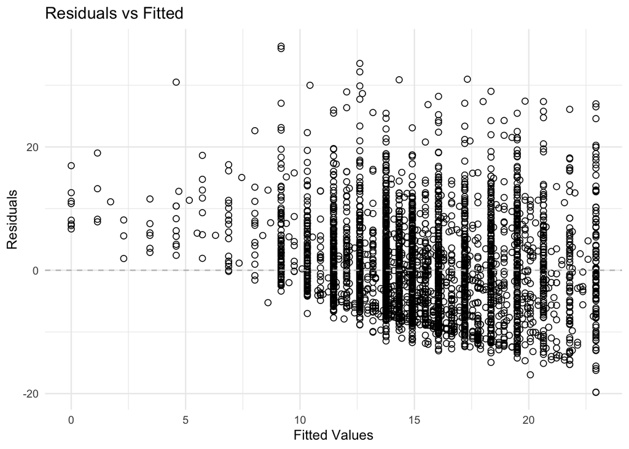

```r
plot.mylm(model5)
```

```r
#anova.mylm(model5)
```

As there is no intercept the for a education of zero there is also a wage of zero now. The parameter for education is greater than with the intercept, as it has to compensate for the missing intercept. Again, the residual plot shows that the errors are higher with a higher dependent variable. Also, the R^2 is smaller. We would recommend adding the intercept.

```r
# Select Build, Build and reload to build and lode into the R-session.

library(stringr)

mylm <- function(formula, data = list(), contrasts = NULL, ...){
  # Extract model matrix & responses
  mf <- model.frame(formula = formula, data = data)
  X  <- model.matrix(attr(mf, "terms"), data = mf, contrasts.arg = contrasts)
  y  <- model.response(mf)
  terms <- attr(mf, "terms")


  # Add code here to calculate coefficients, residuals, fitted values, etc...
  # coefficients
  coeff <- solve(t(X) %*% X) %*% t(X) %*% y
  coeff_list <- as.list(coeff[,1])

  # Assign names to coefficients
  names(coeff_list) <- colnames(X)

  # fitted values
  fitted_values <- X %*% coeff
  #residuals
  residuals <- y - fitted_values


  TSS <- sum((y-mean(y))^2)

  # and store the results in the list est
  est <- list(terms = terms, model = mf)

  # Store call and formula used
  est$call <- match.call()
  est$formula <- formula
  est$coeff <- coeff_list
  est$rank <- length(colnames(X))
  est$fitted_values <- fitted_values
  est$residuals <- residuals

  est$dof_residuals <- nrow(X) - length(colnames(X)) - 1
  est$data_matrix <- X
  est$TSS <- TSS


  # Set class name. This is very important!
  class(est) <- 'mylm'

  # Return the object with all results
  return(est)
}

print.mylm <- function(object, ...){
  # Code here is used when print(object) is used on objects of class "mylm"
  # Useful functions include cat, print.default and format
  variable_names = all.vars(object$formula)

  cat('Call:\n')
  print(object$call)
  cat('\nCoefficients:\n')
  for (name in names(object$coeff)) {
    cat(name, ': ')
    cat(format(object$coeff[[name]], digits = 4, nsmall = 4), '\n')
  }
}

summary.mylm <- function(object, ...){
  # Code here is used when summary(object) is used on objects of class "mylm"
  # Useful functions include cat, print.default and format

  #
  X <- object$data_matrix
  RSS <- sum(object$residuals^2)
  sigma2 <- RSS/object$dof_residuals
  XtX_inv <- solve(t(X)%*%X)
  cov_matrix <- sigma2*XtX_inv
  stderr <- sqrt(diag(cov_matrix))


  # z and p values
  z <- as.numeric(object$coeff) / as.numeric(stderr)
  p <- 2 * (1 - pnorm(abs(z)))

  # significance levels
  sig_level <- list()
  for (value in p) {
    # Determine the significance level and append to the list
    if (value < 0.001) {
      sig_level[[length(sig_level) + 1]] <- '***'
    } else if (value < 0.01) {
      sig_level[[length(sig_level) + 1]] <- '**'
    } else if (value < 0.05) {
      sig_level[[length(sig_level) + 1]] <- '*'
    } else if (value < 0.1) {
      sig_level[[length(sig_level) + 1]] <- '.'
    } else {
      sig_level[[length(sig_level) + 1]] <- ' '
    }
  }


  ## Call
  cat('Call:\n')
  print(object$call)

  ## Residuals
  # set up values
  summary_residuals <- c(
    Min = min(object$residuals),
    Q1 = quantile(object$residuals, 0.25),
    Median = median(object$residuals),
    Q3 = quantile(object$residuals, 0.75),
    Max = max(object$residuals)
  )
  formatted_residuals <- format(summary_residuals, digits = 4, nsmall = 3,justify = "right", trim = TRUE)
  max_width <- max(nchar(formatted_residuals))
  formatted_residuals <- format(summary_residuals, digits = 4, nsmall = 3, justify = "right", trim = TRUE)

  # printing
  cat('\nResiduals:\n')

  cat(str_pad("Min", max_width+2, side = 'right'),
      str_pad("1Q", max_width+2, side = 'right'),
      str_pad("Median", max_width+2, side = 'right'),
      str_pad("3Q", max_width+2, side = 'right'),
      str_pad("Max", max_width+2, side = 'right'), "\n")
  cat(str_pad(formatted_residuals[1], max_width+2, side = 'right'),
      str_pad(formatted_residuals[2], max_width+2, side = 'right'),
      str_pad(formatted_residuals[3], max_width+2, side = 'right'),
      str_pad(formatted_residuals[4], max_width+2, side = 'right'),
      str_pad(formatted_residuals[5], max_width+2, side = 'right'), "\n")




  cat('\nCoefficients:\n')
  max_name = max(nchar(names(object$coeff)))
  formatted_coeff<- format(object$coeff, nsmall = 4,justify = "right", trim = TRUE)
  max_width <- max(nchar(formatted_coeff))
  formatted_coeff <- format(object$coeff, nsmall = 4, justify = "right", trim = TRUE)


  cat(strrep(" ", max_name+2),
      str_pad('Estimate', max_width+3, 'right'),
      str_pad('Std. Error', max_width+3, 'right'),
      str_pad("z value", max_width+3, 'right'),
      str_pad( "Pr(>|z|)", max_width+3, 'right'), '\n')
  i <- 1
  for (name in names(object$coeff)) {
    cat(str_pad(name, max_name+3, 'right'))
    cat(
        str_pad(formatted_coeff[[name]], max_width+3, 'right'),
        str_pad(format(stderr[i], digits = 1, nsmall = 4, justify = "right", trim = TRUE), max_width+3, 'right'),
        str_pad(format(z[i], digits = 1, nsmall = 4, justify = "right", trim = TRUE), max_width+3, 'right'),
        str_pad(paste(format(p[i], digits = 1, nsmall = 4, justify = "right", trim = TRUE), sig_level[i]), max_width+3, 'right'),
        '\n')
    i <- i+1
  }

  R_sqrd <- 1-(RSS/object$TSS)
  F_stat <- ((object$TSS-RSS)/(object$rank-1))/(RSS/object$dof_residuals )
  p_value_f <- 1 - pf(F_stat, df1 = object$rank - 1, df2 = object$dof_residuals)

  cat('\nSignif. codes:  0 ‘***’ 0.001 ‘**’ 0.01 ‘*’ 0.05 ‘.’ 0.1 ‘ ’ 1\n')

  cat('Residual standard error: ', format(sqrt(sigma2), digits=4), 'on ', object$dof_residuals,'degrees of freedom', '\n') # values missing
  cat('Multiple R-squared: ', format(R_sqrd, digits=4), ', ', 'Adjusted R-squared: ', format(1-((1-R_sqrd)*(nrow(X)-1)/object$dof_residuals), digits=4), "\n")
  cat('F-statistic: ', format(F_stat,digits = 1, nsmall = 1), 'on',object$rank-1, 'and',object$dof_residuals ,'DF, p-value:', format(p_value_f ,digits = 1, nsmall = 3),'\n' )

}

plot.mylm <- function(object, ...){
  # Code here is used when plot(object) is used on objects of class "mylm"

  library(ggplot2)
  # ggplot requires that the data is in a data.frame, this must be done here
  data_plot <- data.frame(Fitted = object$fitted_values, Residuals=object$residuals)

    ggplot(data_plot, aes(x=Fitted, y=Residuals)) + geom_point(shape = 1, size = 2) +
      ggtitle('Residuals vs Fitted') +
      labs(x = 'Fitted Values', y = 'Residuals') +
      geom_hline(yintercept = 0, linetype = "dashed", color = "grey") +
      theme_minimal()

  # if you want the plot to look nice, you can e.g. use "labs" to add labels, and add colors in the geom_point-function

}

anova.mylm <- function(object, ...){
  # Code here is used when anova(object) is used on objects of class "mylm"

  # Components to test
  comp <- attr(object$terms, "term.labels")

  # Name of response
  response <- deparse(object$terms[[2]])

  # Total Sum of Squares (TSS)
  TSS <- sum((object$model[[response]] - mean(object$model[[response]]))^2)

  # Fit the sequence of models
  txtFormula <- paste(response, "~", sep = "") # for the formula for lm
  print(txtFormula)
  model <- list()
  RSS <- numeric(length(comp) + 1)  # empty to store RSS
  df <- numeric(length(comp) + 1)   # empty to store df

  # First model (only intercept)
  RSS[1] <- TSS
  df[1] <- nrow(object$model) - 1


  # Fit the sequence of models
  txtFormula <- paste(response, "~", sep = "")
  model <- list()
  for(numComp in 1:length(comp)){
    if(numComp == 1){
      txtFormula <- paste(txtFormula, comp[numComp])
    }
    else{
      txtFormula <- paste(txtFormula, comp[numComp], sep = "+")
    }
    formula <- formula(txtFormula)
    model[[numComp]] <- lm(formula = formula, data = object$model)
    # Fit the new model and calculate RSS
    model[[numComp]] <- lm(formula = formula, data = object$model)
    RSS[numComp + 1] <- sum(model[[numComp]]$residuals^2)
    df[numComp + 1] <- model[[numComp]]$df.residual
  }
  # empty list to store values
  anova_table <- list()

  # Loop through the models and calculate stats
  for (numComp in 1:length(comp)) {
    # Calculate difference in RSS
    SS_diff <- RSS[numComp] - RSS[numComp + 1]
    df_diff <- df[numComp] - df[numComp + 1]
    MS_diff <- SS_diff / df_diff  # Mean square for the model
    MS_residual <- RSS[numComp + 1] / df[numComp + 1]  # for Chi^2 statistic

    # Chi^2 statistic
    chi_sq <- SS_diff / MS_residual

    # P-value from Chi-squared distribution
    p_value <- pchisq(chi_sq, df_diff, lower.tail = FALSE)

    # Store the values in the list
    anova_table[[numComp]] <- c(df_diff, SS_diff, MS_diff, chi_sq, p_value)
  }

  # Convert the list to df
  anova_df <- as.data.frame(do.call(rbind, anova_table))
  colnames(anova_df) <- c("Df", "Sum_Sq", "Mean_Sq", "Chi^2", "Pr(>Chi)")

  anova_df[["Sum_Sq"]] <- round(anova_df[["Sum_Sq"]], 0)
  anova_df[['Mean_Sq']] <- round(anova_df[['Mean_Sq']], 0)
  anova_df[['Chi^2']] <- round(anova_df[['Chi^2']], 3)
  anova_df[['Pr(>Chi)']] <- round(anova_df[['Pr(>Chi)']], 3)


  # Define the significance function
  get_significance <- function(p_value) {
    if (p_value < 0.001) {
      return("***")
    } else if (p_value < 0.01) {
      return("**")
    } else if (p_value < 0.05) {
      return("*")
    } else if (p_value < 0.1) {
      return(".")
    } else {
      return(" ")
    }
  }
  anova_df$Signif <- sapply(as.numeric(anova_df[['Pr(>Chi)']]), get_significance)

  # Find max for formatting
  max_lengths <- sapply(anova_df, function(col) max(nchar(as.character(col))))
  max_width <- max(max_lengths)
  max_name = max(nchar(names(object$coeff)))

  # Prepare to print ANOVA table with formatted widths
  cat('Analysis of Variance Table\n')
  cat(c('Response: ', response, '\n'), sep = '')

  cat(strrep(" ", max_name+2),
      str_pad('Df', max_width+3, 'right'),
      str_pad('Sum Sq', max_width+3, 'right'),
      str_pad("Mean Sq", max_width+3, 'right'),
      str_pad("Chi^2", max_width+3, 'right'),
      str_pad( "Pr(>Chi^2)", max_width+3, 'right'), '\n')
  i <- 1
  for (i in 1:nrow(anova_df)) {
    cat(str_pad(comp[i], max_name+3, 'right'))
    cat(
      str_pad(anova_df[i, "Df"], max_width+3, 'right'),
      str_pad(anova_df[i, "Sum_Sq"], max_width+3, 'right'),
      str_pad(anova_df[i, "Mean_Sq"], max_width+3, 'right'),
      str_pad(anova_df[i, "Chi^2"], max_width+3, 'right'),
      str_pad(paste(anova_df[i, "Pr(>Chi)"],anova_df$Signif), max_width+3, 'right'),
      '\n')
    i <- i+1
  }

  residual_SumSq <- RSS[1] - sum(as.numeric(anova_df$Sum_Sq))
  residual_Mean_Sq <- residual_SumSq/object$dof_residuals
  cat(str_pad('Residuals', max_name+2, 'right'),
      str_pad(object$dof_residuals, max_width+3, 'right'),
      str_pad(round(residual_SumSq), max_width+3, 'right'),
      str_pad(round(residual_Mean_Sq), max_width+3, 'right'))
  cat('\nSignif. codes:  0 ‘***’ 0.001 ‘**’ 0.01 ‘*’ 0.05 ‘.’ 0.1 ‘ ’ 1\n')
  cat('Total Sum SQ:', round(object$TSS), '\n')

  # chi squared test
  chi2_stat <- (object$TSS - residual_SumSq) / (residual_SumSq / object$dof_residuals)
  p_value_chi2 <- 1 - pchisq(chi2_stat, df = object$rank - 1)
  cat('Chi-statistic: ', format(chi2_stat,digits = 1, nsmall = 1), 'on', object$dof_residuals ,'DF, p-value:', format(p_value_chi2 ,digits = 1, nsmall = 3),'\n' )

  #return(model)

}
```